# QC_Analysis_of_ICB_Riaz.Rmd

Nasim Bondar Sahebi

UofT, Princess Margaret Cancer Center, University Health Network, Toronto, Ontario, Canada

2024-09-15

## load libraries

```r
library(MultiAssayExperiment)
library(ggplot2)
library(dplyr)
library(ComplexHeatmap)
library(DESeq2)
library(gridExtra)
library(DT)
library(survival)
library(survminer)
```

## Data Loading and Preparation

**Data Overview**:

- **Study Reference**: [PubMed ID 29033130](https://pubmed.ncbi.nlm.nih.gov/29033130/)
- **Patient Count** : 83
- **Treatment counts**:
- **IO+combo**: 43
- **PD-1/PD-L1**: 40

Load multiassay .rds file, extract clinical, expression and annotations data; prepare gene expression data for analysis.

```r
# Load your multiassay result and extract clinical data , expression data and annotation

#load mae obj
mae <- readRDS("~/BHK lab/ICB/ICB_Riaz/output/ICB_Riaz.rds")

#extract Clinical data
clin <- data.frame(colData(mae)) # Dim 83x 44

# assay names:  "expr_gene_tpm", "expr_gene_counts", "expr_isoform_tpm", "expr_isoform_counts" and "snv"
names(mae)
```

```
## [1] "expr_gene_tpm"       "expr_gene_counts"    "expr_isoform_tpm"
## [4] "expr_isoform_counts" "snv"
```

```r
#extract the expression data and snv
expr <- assays(mae)[["expr_gene_tpm"]] # Dim 61544 x 51
snv <- assays(mae)[["snv"]]

#extracting the annotation
annot_expr <- data.frame(rowData(mae@ExperimentList$expr_gene_tpm))
annot_snv <- data.frame(rowData(mae@ExperimentList$snv))

# Display first few rows of the data set.
DT::datatable(expr[1:8, 1:4])
```

|  | SRR5088813 | SRR5088815 | SRR5088818 | SRR5088819 |
| --- | --- | --- | --- | --- |
| ENSG00000000003.15 | 4.18312029607164 | 3.69561447812745 | 4.18834641046022 | 5.57939246874917 |
| ENSG00000000005.6 | -5.15946432800923 | -9.96578428466209 | -4.17974790859394 | -9.96578428466209 |
| ENSG00000000419.14 | 5.73890594784945 | 5.41633582720806 | 6.23246595311413 | 5.26320234035916 |
| ENSG00000000457.14 | 3.0154102224739 | 2.27089945931298 | 2.06445394603706 | 3.23336930687673 |
| ENSG00000000460.17 | 3.31497154155665 | 3.44341646279333 | 2.1761952154706 | 3.42359033743152 |
| ENSG00000000938.13 | 3.97789856653494 | 4.53403594701081 | 3.78485765791492 | -0.262189705513575 |
| ENSG00000000971.17 | 5.09259454668503 | 6.05382457625516 | 6.31565666392539 | 2.58639888603682 |
| ENSG00000001036.14 | 6.48358754879127 | 5.66111536450559 | 6.71621284281487 | 4.04392780815364 |

## Pre-therapy Tumor Gene Expression Analysis

#### 1. **Paper Methodology**:

- **DEGs Identified**: 189 DEGs (q-value < 0.20) between responders (CR/PR) and non-responders (PD) based on pre-therapy tumor biopsies.
- **Normalization**: RNA-seq data was normalized using regularized-logarithm transformation (rlog) for variance stabilization before clustering.

#### 2. **Our Analysis**:

```r
# Load necessary librarieses

expr <- assays(mae)[["expr_gene_counts"]]
annot <- data.frame(rowData(mae@ExperimentList$expr_gene_counts))
clin <- data.frame(colData(mae))

# Recode response categories for DEGs analysis
clin$response_paper <- ifelse(clin$recist %in% c("PR", "CR"), "Responder", "Non_Responder")

# Ensure matching gene IDs and filtering invalid genes
expr <- expr[match(rownames(expr), annot$gene_id), ]
valid_genes <- !is.na(annot$gene_name) & !duplicated(annot$gene_name)
expr <- expr[valid_genes, ]
rownames(expr) <- annot$gene_name[valid_genes]
DT::datatable(expr[1:8, 1:4])
```

|  | SRR5088813 | SRR5088815 | SRR5088818 | SRR5088819 |
| --- | --- | --- | --- | --- |
| TSPAN6 | 10.5453356189242 | 10.3525979356835 | 10.6292939209635 | 12.3826628212705 |
| TNMD | 1 | 0 | 1.58496250072116 | 0 |
| DPM1 | 10.8505639785648 | 10.5443355210604 | 11.3238401943191 | 10.7125576860801 |
| SCYL3 | 9.9214212228753 | 9.32781142796466 | 9.02971848588818 | 10.612973444393 |
| C1orf112 | 9.99347676594097 | 10.0727674327209 | 8.84516350932358 | 10.4204146191407 |
| FGR | 10.1344263202209 | 10.8281364841941 | 9.97441458980553 | 6.2667865406949 |
| CFH | 11.8684791679862 | 12.9053911507779 | 13.0279311308028 | 9.92022853858828 |
| FUCA2 | 12.756987210368 | 12.0244247348749 | 12.9777077135974 | 10.7124920675798 |

```r
# Filter clinical data to include only patients present in both datasets
clin <- clin[!is.na(clin$recist), ]
patients <- intersect(clin$patientid, colnames(expr))
clin_expr <- clin[patients, ] # 51 x 43 samples
expr <- expr[, patients]  # 61544 x 51

# Create DESeq2 dataset
dds <- DESeqDataSetFromMatrix(countData = round(expr), colData = clin_expr, design = ~response_paper)

# Run DESeq2 analysis
dds <- DESeq(dds)

# Get results with p-value < 0.20
res <- results(dds)

# Filter for significant genes (p-value < 0.05)
res_sig <- res[which(res$pvalue < 0.05),]

# Number of DEGs
length(rownames(data.frame(res_sig))) # DEGs 387
```

```
## [1] 362
```

```r
# Display significant DEGs using DT
res_sig_filtered <- res_sig[!grepl("^ENS", rownames(res_sig)), ] #224 DEGs now
DT::datatable(data.frame(res_sig[1:13, 1:6]), caption = "All Significant DEGs (padj < 0.05)")
```

|  | baseMean | log2FoldChange | lfcSE | stat | pvalue | padj |
| --- | --- | --- | --- | --- | --- | --- |
| TKTL1 | 5.686756136479334 | -0.6124934541021104 | 0.2709943529698659 | -2.260170543739037 | 0.02381066827319016 | 0.9999672887201236 |
| BEST2 | 1.875194913685514 | -1.080129646840599 | 0.5496932561390842 | -1.964967979463992 | 0.04941794373745383 | 0.9999672887201236 |
| EPN3 | 2.805574247584931 | -1.176547178727616 | 0.5525277073426054 | -2.129390369192971 | 0.03322197660258351 | 0.9999672887201236 |
| PRSS8 | 3.95503104259988 | -0.9138136090866451 | 0.3894739774741303 | -2.34627641880732 | 0.01896203889587858 | 0.9999672887201236 |
| GLP2R | 2.024243519966718 | 1.345295117539591 | 0.6394003219186659 | 2.103995058217561 | 0.03537887808694309 | 0.9999672887201236 |
| PPP2R2C | 3.55434310332542 | -0.9055675218457427 | 0.4604610630777615 | -1.966653848629135 | 0.0492231309084243 | 0.9999672887201236 |
| PKP1 | 5.50182491143558 | -0.6928874309203529 | 0.3147721828093694 | -2.201234634954943 | 0.02771941756134824 | 0.9999672887201236 |
| P2RX5 | 5.615304160449332 | 0.4930591884779232 | 0.2220526253031176 | 2.220460973180851 | 0.02638749205830438 | 0.9999672887201236 |
| SULT2B1 | 3.920662483751255 | -0.7059151990808492 | 0.3487562234714145 | -2.024093482990445 | 0.04296053404306137 | 0.9999672887201236 |
| CRTAC1 | 10.06275225304532 | -0.4226315011735944 | 0.1915010342574458 | -2.206941089443029 | 0.02731817529140849 | 0.9999672887201236 |

[output cut: 3 more lines]

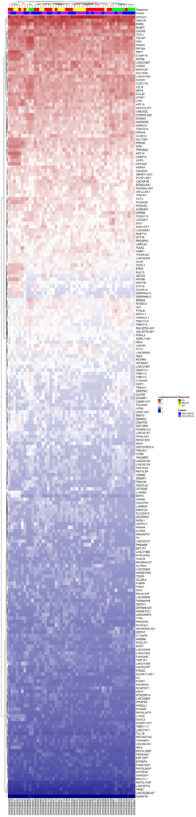

```r
# normlize expr as it follo w the paper
expr <- assay(rlog(dds, blind = FALSE))

# Filter expression matrix to include only DEGs

expr_degs <- expr[rownames(expr) %in% rownames(data.frame(res_sig))& !grepl("^ENS", rownames(expr)), ]


clin_expr$recist <- ifelse(clin_expr$recist %in% c("PR", "CR"), "PR/CR", clin_expr$recist)


# Create annotations based on clinical data
annotations <- data.frame(
  Response = clin_expr$recist,
  Cohort = clin_expr$Cohort
)

rownames(annotations) <- rownames(clin_expr)

# Define colors for annotations
response_colors <- c("PD" = "red", "SD" = "yellow", "PR/CR" = "green")
cohort_colors <- c("NIV3-NAIVE" = "blue", "NIV3-PROG" = "purple")

# Create heatmap annotations
ha <- HeatmapAnnotation(df = annotations, col = list(Response = response_colors, Cohort = cohort_colors))

# Set up heatmap colors
heatmap_colors <- colorRampPalette(c("navy", "white", "firebrick"))(100)

# Generate the heatmap

Heatmap(expr_degs,
        name = "Log2(expression)",
        top_annotation = ha,
        col = heatmap_colors,
        cluster_rows = TRUE,
        cluster_columns = TRUE)
```

## Analysis of Ipi-Naive Patients by Mutation Load

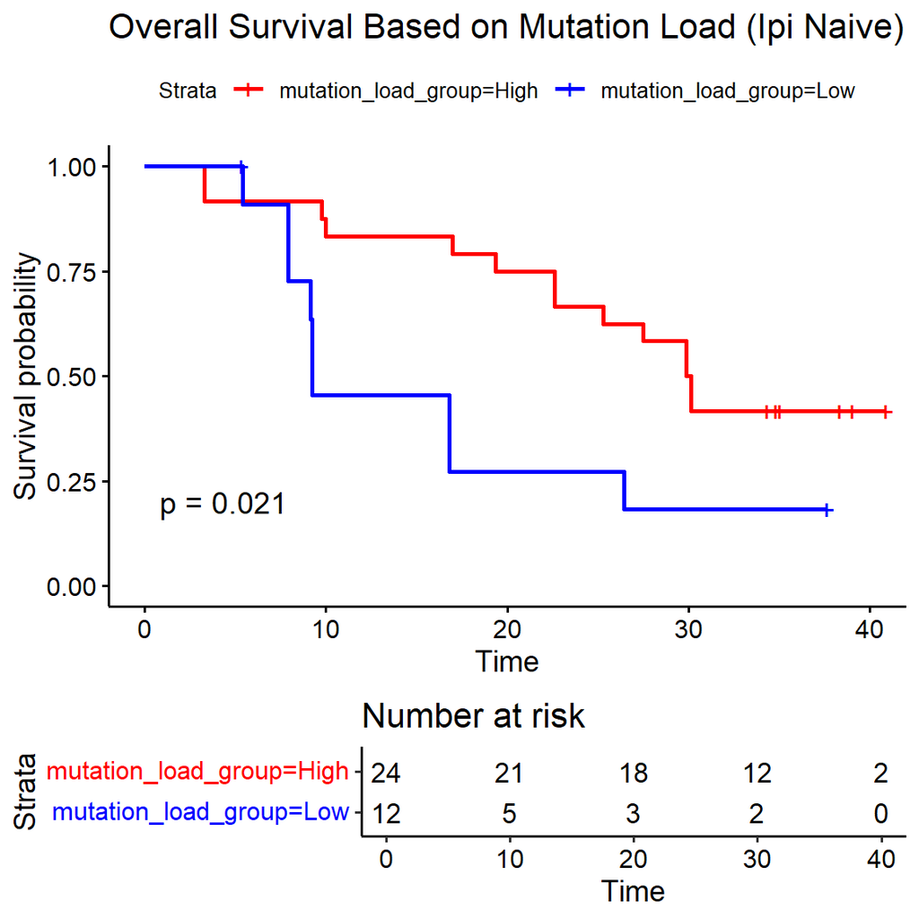

```r
#Figure 1B : "NIV3-NAIVE"

# Create subset for Ipi Naive cohort with complete case analysis for necessary columns
clin_naive <- clin %>%
  filter(Cohort == "NIV3-NAIVE", !is.na(Mutation.Load))

# Calculate median mutation load if the subset is not empty

  clin_naive$mutation_load_group <- ifelse(clin_naive$Mutation.Load > 100, "High", "Low")

  # Prepare the survival object
  surv_object <- Surv(time = clin_naive$survival_time_os, event = clin_naive$event_occurred_os)

  # Fit the survival model based on mutation load groups
  fit <- survfit(surv_object ~ mutation_load_group, data = clin_naive)

  # Plot the Kaplan-Meier survival curves
  ggsurvplot(
    fit,
    data = clin_naive,
    risk.table = TRUE,
    pval = TRUE,
    title="Overall Survival Based on Mutation Load (Ipi Naive)",
    palette = c("red", "blue")
  )
```

## NIV3-PROG High Mutation Load Analysis

For the “NIV3-PROG” cohort, we assess the impact of a high mutation load (defined as >100 mutations) on overall survival. Previous analyses reported no significant association between high mutation load and OS in patients who progressed on ipilimumab (Ipi-P), which is confirmed by our log-rank test.

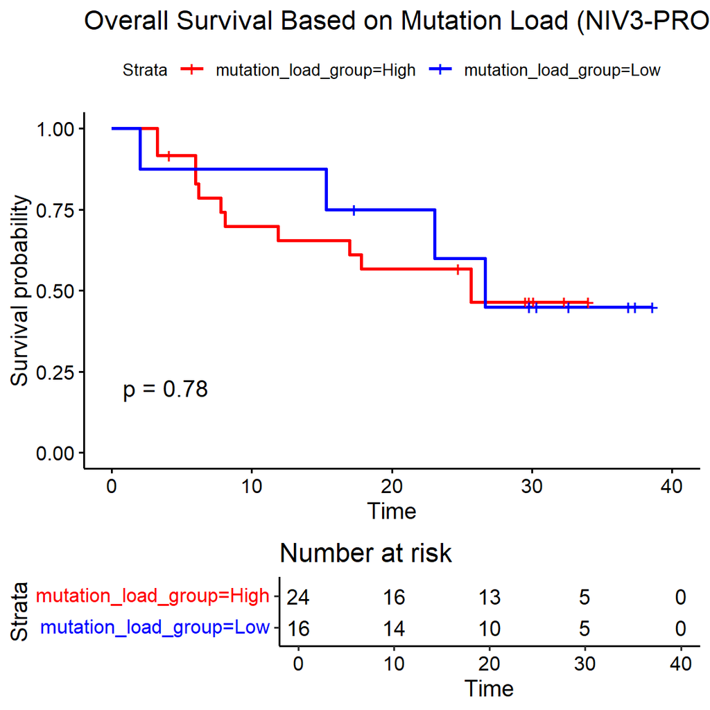

```r
# Figure S1 : NIV3-PROG

library(dplyr)
library(survival)
library(survminer)

# Create subset for Ipi Naive cohort with complete case analysis for necessary columns
clin_prog <- clin %>%
  filter(Cohort == "NIV3-PROG", !is.na(Mutation.Load))

# Calculate median mutation load if the subset is not empty

  clin_prog$mutation_load_group <- ifelse(clin_prog$Mutation.Load > 100, "High", "Low")

  # Prepare the survival object
  surv_object <- Surv(time = clin_prog$survival_time_os, event = clin_prog$event_occurred_os)

  # Fit the survival model based on mutation load groups
  fit <- survfit(surv_object ~ mutation_load_group, data = clin_prog)

  # Plot the Kaplan-Meier survival curves
  ggsurvplot(
    fit,
    data = clin_prog,
    risk.table = TRUE,
    pval = TRUE,
    title="Overall Survival Based on Mutation Load (NIV3-PROG)",
    palette = c("red", "blue")
  )
```